# Test 1

2024-10-20

# Question 1

**kNN:** kNN, or k-Nearest Neighbour Classification works by classifying a data point based on its “nearest neighbor”, which is usually measured using points by Euclidean distance. kNN would classify new points as y=1 or y=0 by checking what its nearest neighbors are classified as. If most of the nearby points are inside the circle with radius 5, the new point would be classified as y=0, and y=1 if nearby points are outside the circle. Euclidean distance would work well in this case, since the “boundary” is circular. Regarding tuning, I would choose a low k value, like k=1, k=3 or k=5; this would cause the model to be more sensitive, and rely on the closest one, three, or five neighbors. I think this would work well for general predictions, but the kNN might fail when classifying points that are on/near the border of the circle, as that might lead to inaccurate classifications if the nearest points are on the other side of the border. Additionally, since kNN works by taking the majority, I would choose an odd number for a k-value. Overall, I think kNN would perform well with this relationship, as it doesn’t make any assumptions about the data and relies on Euclidean distance to make predictions.

**LDA:** LDA, or linear discriminant analysis works by finding a linear combination of the input variables to separate the two outcomes (y=1 or y=2). Since the boundary in this question is non-linear(circular), I’m not sure that any tuning would help, as LDA would not recognize the circular boundary.

**Decision Tree:** A decision tree breaks down a data set into smaller subsets based on variable conditions. To tune the tree so that it would recognize the circular boundary, I would control the tree’s depth using maxdepth and set a higher depth. This would allows the tree to create more splits, helping it approximate the circular boundary. I would also fiddle with complexity parameter (cp), I think I would set it lower cp to increase splits, to approximate the circular boundary.

# Question 2

The scenario would be absolutely terrible if the model was just guessing randomly, and unable to distinguish between Class A and Class B beyond random chance, and just predicts with 50% accuracy by guessing randomly (like flipping a coin). This would be terrible because a model that just predicts Class A would already achieve 95% percent accuracy, so it would be even worse than that. One example could be detecting a type of cancer in patients, where class A (95%) indicated no cancer/healthy, while class B (5%) indicated cancer/unhealthy. In this terrible case, it would predict that for every healthy person, there’s a 50% chance the model says they have cancer, and for every person with cancer, there’s a 50% chance the model says they’re not healthy. The model would basically do nothing.

The scenario would be very mediocre if it achieved 50% accuracy by assigning observations in Class A to Class B (and from class B to class A. This is better than absolutely terrible (which is just guessing randomly), but it would still misclassify a lot, but at least it is not doing it randomly. Going back to the cancer example, in this mediocre case, it would correctly assign some patients with cancer, but it would also incorrectly classify some patients who don’t have cancer with cancer (thats ok, but not great). However, it would correctly classify patients who don’t have cancer, and would incorrectly classify patients who have cancer with not having cancer (this is really bad). Overall, it would not be great, but still better than randomly choosing.

The model would be quite impressive if the model successfully predicted all 5% in class B, classified 45% of class A correctly, and then incorrectly classified the rest of class A as class B. In the cancer example, this would be if it correctly classified all 5% of patients who have cancer with cancer, and then correctly classified 45% percent of healthy patients as healthy. The shortfall is that it would incorrectly classify 50% of healthy people with having cancer, but this is less important because all patients with cancer will end up being treated. The patients who had false positives could get second opinions.

# Question 3

```r
stroke_data <- read_csv("/Users/michaelhe/Desktop/Stat 0218/Data Sets/stroke_data.csv")
stroke_cleaned <- stroke_data |>
  mutate(bmi = na_if(bmi, "n/a")) |>
  mutate(bmi = as.numeric(bmi)) |>
  drop_na(bmi)
```

```r
#This is from ChatGPT I physically could not figure out how to remove NAs
```

Here are some exploratory graphs to decide which variables to choose (I decided to choose 3 variables, similar to our last homework). I decided to choose heart disease, age, and average glucose level as my three variables as I thought that they had the biggest differences between “no stroke” and “stroke”

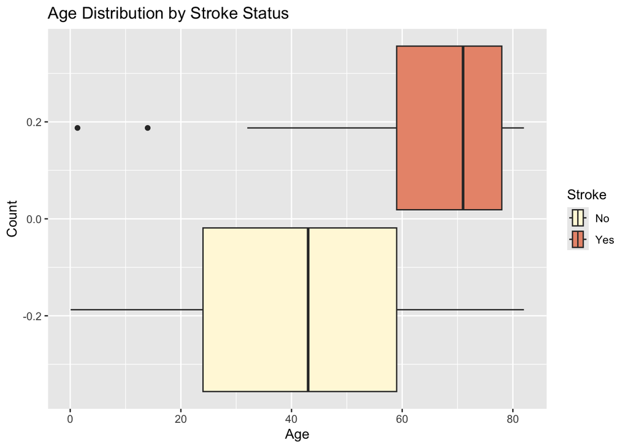

```r
stroke_data |>
ggplot() +
  geom_boxplot(aes(x=age, fill = factor(stroke))) +
  labs(title = "Age Distribution by Stroke Status", x = "Age", y = "Count", fill = "Stroke")+
  scale_fill_manual(values = c("0" = "cornsilk", "1" = "darksalmon"), labels = c("0" = "No", "1" = "Yes"))
```

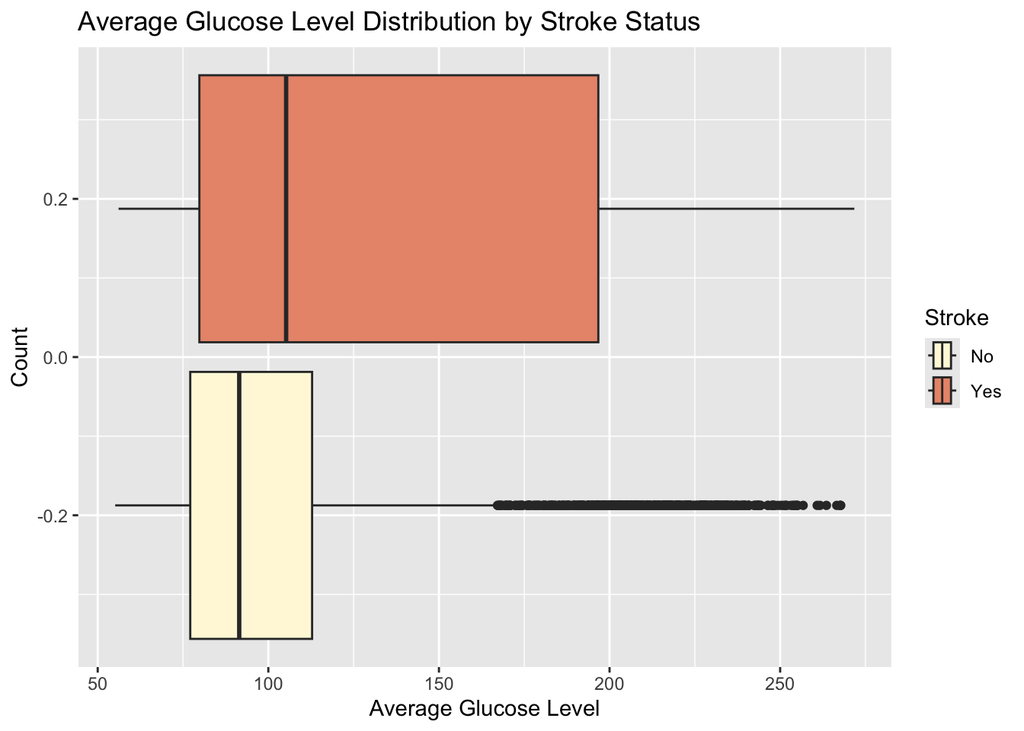

```r
#there is a difference

stroke_data |>
  ggplot () +
  geom_boxplot(aes(x = avg_glucose_level, fill = factor(stroke))) +
  labs(title = "Average Glucose Level Distribution by Stroke Status", x = "Average Glucose Level",
       y = "Count", fill = "Stroke") +
  scale_fill_manual(values = c("0" = "cornsilk", "1" = "darksalmon"), labels = c("0" = "No", "1" = "Yes"))
```

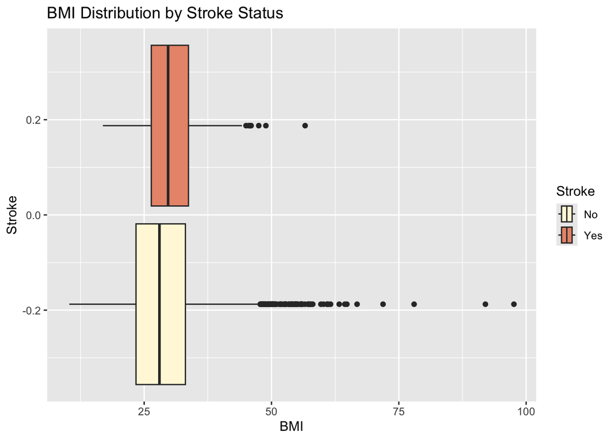

```r
#there is a difference


stroke_cleaned |>
  ggplot() +
  geom_boxplot(aes(x = bmi, fill = factor(stroke))) +
  labs(title = "BMI Distribution by Stroke Status", x = "BMI", y = "Stroke", fill = "Stroke") +
  scale_fill_manual(values = c("0" = "cornsilk", "1" = "darksalmon"), labels = c("0" = "No", "1" = "Yes"))
```

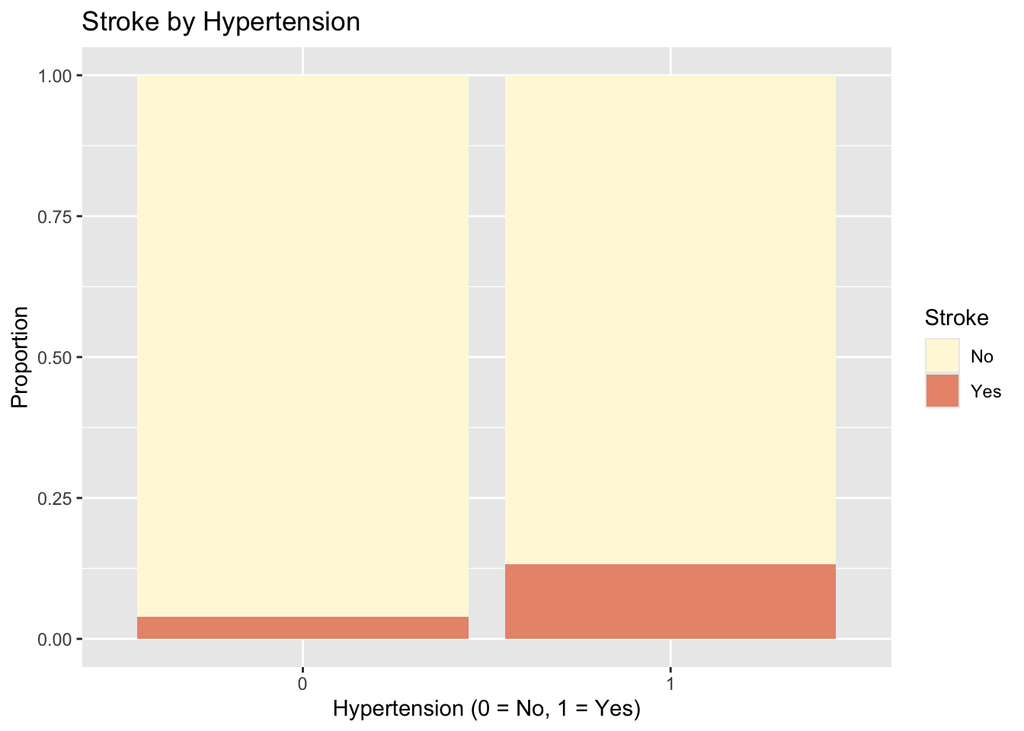

```r
#After all my work, BMI doesn't make a difference :(

stroke_data |>
ggplot() +
  geom_bar(aes(x = factor(hypertension), fill = factor(stroke)), position = "fill") +
  labs(title = "Stroke by Hypertension", x = "Hypertension (0 = No, 1 = Yes)", y = "Proportion", fill = "Stroke")+
  scale_fill_manual(values = c("0" = "cornsilk", "1" = "darksalmon"), labels = c("0" = "No", "1" = "Yes"))
```

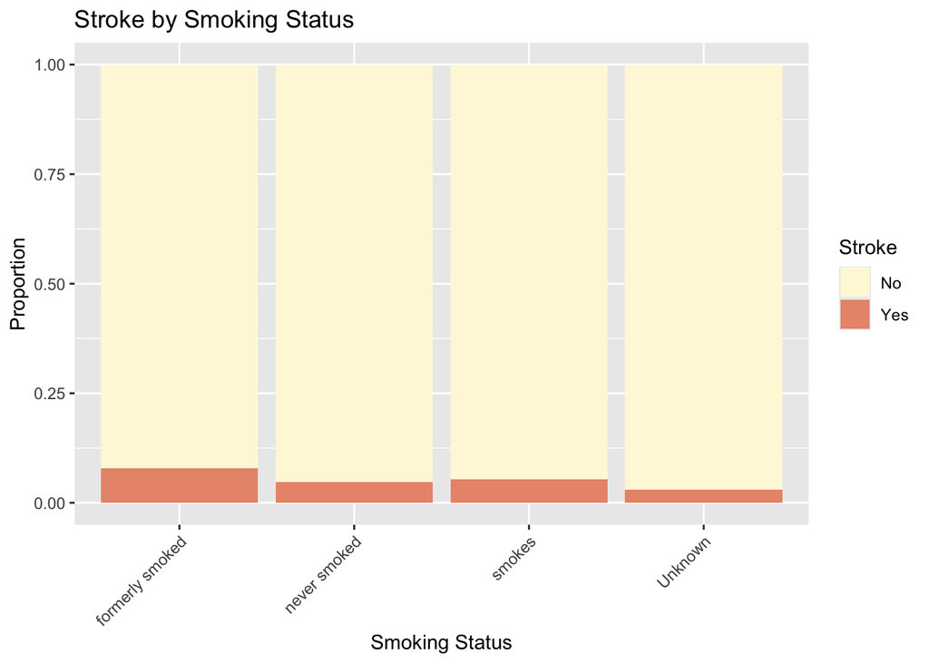

```r
#Yes difference

stroke_data |>
  ggplot() +
  geom_bar(aes(x = smoking_status, fill = factor(stroke)), position = "fill") +
  labs(title = "Stroke by Smoking Status", x = "Smoking Status", y = "Proportion", fill = "Stroke") +
  theme(axis.text.x = element_text(angle = 45, hjust = 1))+
  scale_fill_manual(values = c("0" = "cornsilk", "1" = "darksalmon"), labels = c("0" = "No", "1" = "Yes"))
```

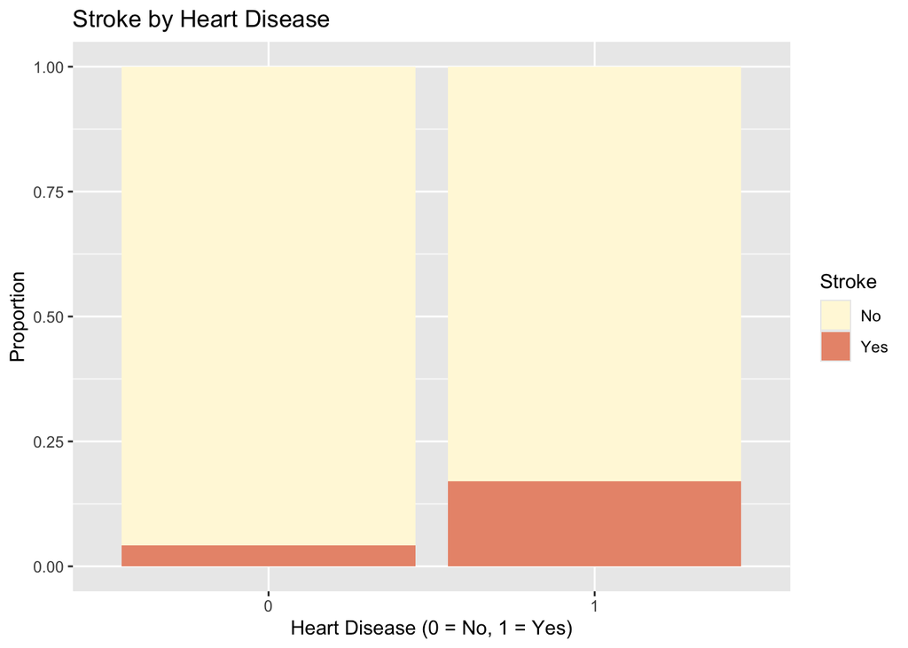

```r
#not much difference

stroke_data|>
  ggplot() +
  geom_bar(aes(x = factor(heart_disease), fill = factor(stroke)),position = "fill") +
  labs(title = "Stroke by Heart Disease", x = "Heart Disease (0 = No, 1 = Yes)", y = "Proportion", fill = "Stroke")+
  scale_fill_manual(values = c("0" = "cornsilk", "1" = "darksalmon"), labels = c("0" = "No", "1" = "Yes"))
```

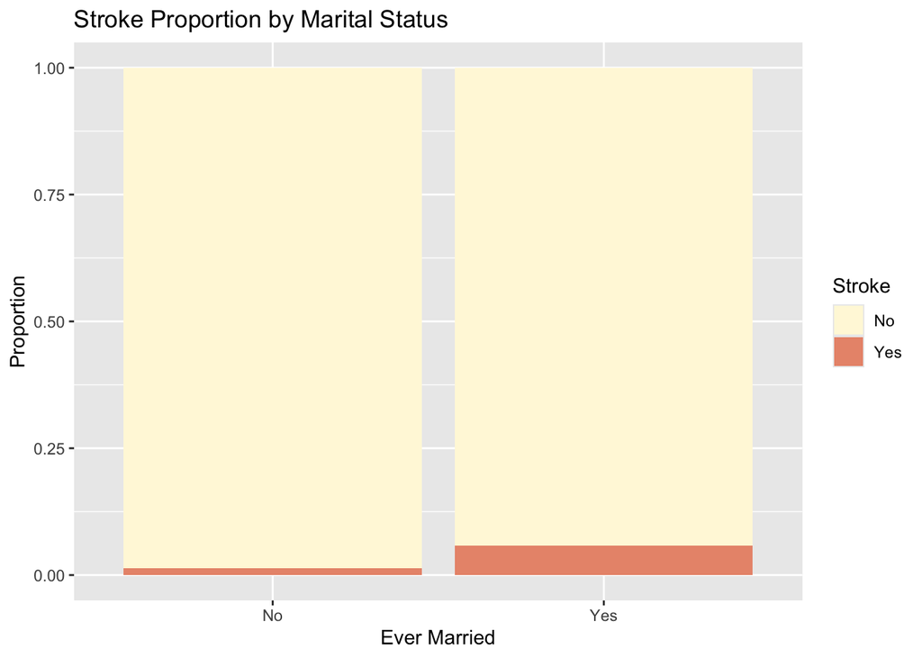

```r
#yes difference

stroke_cleaned |>
  ggplot() +
  geom_bar(aes(x = ever_married, fill = factor(stroke)), position = "fill") +
  labs(title = "Stroke Proportion by Marital Status", x = "Ever Married", y = "Proportion", fill = "Stroke") +
  scale_fill_manual(values = c("0" = "cornsilk", "1" = "darksalmon"), labels = c("0" = "No", "1" = "Yes"))
```

Normalizing Data for kNN and training

```r
stroke_scaled <- stroke_cleaned |>
  na.omit() |>
  mutate(scaled_heart =
           (heart_disease - min(heart_disease))/(max(heart_disease) - min(heart_disease))) |>
  mutate(scaled_age =
           (age - min(age, na.rm=TRUE))/(max(age, na.rm=TRUE)-min(age, na.rm=TRUE))) |>
  mutate(scaled_glucose =
           (avg_glucose_level- min(avg_glucose_level, na.rm=TRUE))/(max(avg_glucose_level, na.rm=TRUE)- min(avg_glucose_level, na.rm=TRUE)))

stroke_thing <- expand_grid(scaled_heart = seq(from = 0, to = 1, by = .05),
                                  scaled_age = seq(from = 0, to = 1, by = .05),
                                  scaled_glucose = seq(from = 0, to = 1, by = .05))

training_rows <- sample(1:nrow(stroke_scaled),
                        size = nrow(stroke_scaled)/2)
train_data <- stroke_scaled[training_rows, ]
test_data <- stroke_scaled[-training_rows, ] |>
  na.omit()
```

Making the kNN: Although the KNN accuracy percentage is pretty high, it predicts zero for everything … which is not ideal at all. I was planning on finding the optimal k value with cross validation, but for every k I put in it predicted no stroke for everything so I didn’t do it.

```r
knn1 <- knn(train = train_data |>
              na.omit() |>
              dplyr::select(scaled_heart, scaled_age, scaled_glucose),
            test = test_data |>
              na.omit() |>
              dplyr::select(scaled_heart, scaled_age, scaled_glucose),
            k = 17,
            cl = train_data$stroke)

knn_predict <- test_data |>
  na.omit() |>
  mutate(knn_prediction = knn1)

accuracy_KNN <- mean(knn_predict$stroke == knn_predict$knn_prediction) * 100

#from chatGPT so sorry Alex:
knn_predict$knn_prediction <- as.factor(knn_predict$knn_prediction)
knn_predict$stroke <- as.factor(knn_predict$stroke)
confusionMatrix(knn_predict$knn_prediction, knn_predict$stroke)
```

```
## Confusion Matrix and Statistics
##
##           Reference
## Prediction    0    1
##          0 2358   97
##          1    0    0
##
##                Accuracy : 0.9605
##                  95% CI : (0.952, 0.9678)
##     No Information Rate : 0.9605
##     P-Value [Acc > NIR] : 0.527
##
##                   Kappa : 0
##
##  Mcnemar's Test P-Value : <2e-16
##
##             Sensitivity : 1.0000
##             Specificity : 0.0000
##          Pos Pred Value : 0.9605
##          Neg Pred Value :    NaN
##              Prevalence : 0.9605
##          Detection Rate : 0.9605
##    Detection Prevalence : 1.0000
##       Balanced Accuracy : 0.5000
##
##        'Positive' Class : 0
##
```

Making the LDA: I would say that LDA or Tree is the best way to predict out of kNN, LDA, and a tree. For LDA, it still is pretty bad (in my opinion), but at least it predicts the a couple strokes out of all three. It also gives a good amount of false positives, but that’s fine. It also predicts a lot of false negatives too though… maybe my variables were bad.

```r
lda1 <- lda(stroke ~ `avg_glucose_level` + age + `heart_disease`,
            data = train_data,
            prior = c(0.9515, 0.0485))

lda_predictions <- predict(lda1, newdata = test_data)$class

lda_predict <- test_data |>
  mutate(lda_pred = lda_predictions)

accuracy_LDA <- mean(lda_predict$stroke == lda_predict$lda_pred) * 100

accuracy_LDA
```

```
## [1] 95.96741
```

```r
confusionMatrix(factor(lda_predictions), factor(test_data$stroke))
```

```
## Confusion Matrix and Statistics
##
##           Reference
## Prediction    0    1
##          0 2349   90
##          1    9    7
##
##                Accuracy : 0.9597
##                  95% CI : (0.9511, 0.9671)
##     No Information Rate : 0.9605
##     P-Value [Acc > NIR] : 0.6079
##
##                   Kappa : 0.114
##
##  Mcnemar's Test P-Value : 8.962e-16
##
##             Sensitivity : 0.99618
##             Specificity : 0.07216
##          Pos Pred Value : 0.96310
##          Neg Pred Value : 0.43750
##              Prevalence : 0.96049
##          Detection Rate : 0.95682
##    Detection Prevalence : 0.99348
##       Balanced Accuracy : 0.53417
##
##        'Positive' Class : 0
##
```

Making the decision tree. The predictions are similar to LDA, as it predicts strokes correctly for some, but then gives false negatives and positives.

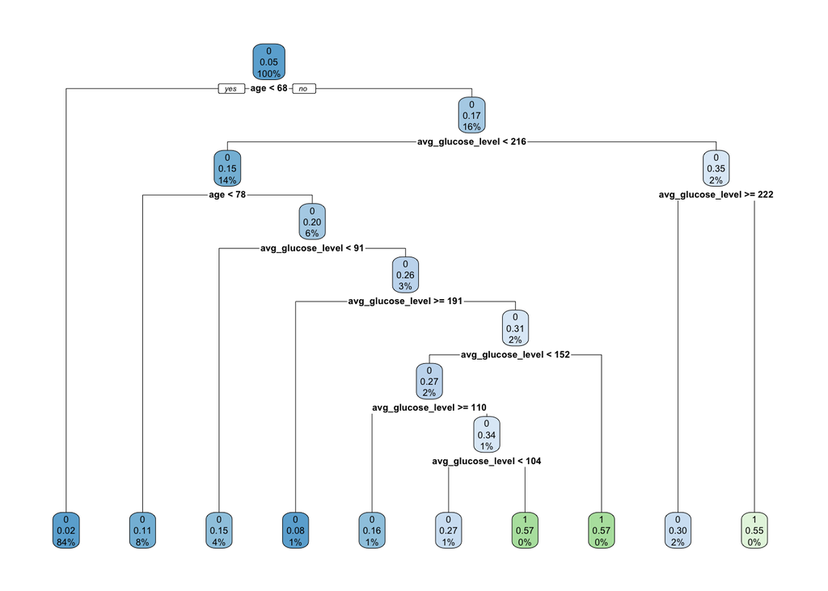

```r
tree1 <- rpart(factor(stroke) ~ `avg_glucose_level` + age +
                 `heart_disease`, data = train_data, cp = 0.0001)

#I chose a lower cp to make the tree grow larger
rpart.plot(tree1)
```

```r
tree_predictions <- predict(tree1, data = train_data, type = "class")

tree_predict <- train_data |>
  mutate(tree_pred = tree_predictions)

accuracy_tree <- mean(tree_predict$stroke == tree_predict$tree_pred) * 100

#this is from chat gpt sorry Alex:
tree_predict$stroke <- as.factor(tree_predict$stroke)
tree_predict$tree_pred <- as.factor(tree_predict$tree_pred)
confusionMatrix(tree_predict$tree_pred, tree_predict$stroke)
```

```
## Confusion Matrix and Statistics
##
##           Reference
## Prediction    0    1
##          0 2331   98
##          1   11   14
##
##                Accuracy : 0.9556
##                  95% CI : (0.9467, 0.9634)
##     No Information Rate : 0.9544
##     P-Value [Acc > NIR] : 0.4098
##
##                   Kappa : 0.1909
##
##  Mcnemar's Test P-Value : <2e-16
##
##             Sensitivity : 0.9953
##             Specificity : 0.1250
##          Pos Pred Value : 0.9597
##          Neg Pred Value : 0.5600
##              Prevalence : 0.9544
##          Detection Rate : 0.9499
##    Detection Prevalence : 0.9898
##       Balanced Accuracy : 0.5602
##
##        'Positive' Class : 0
##
```

# Question 4

It makes sense that the cost of a false positive would be C, while the cost of a false positive would be ten times higher at 10 C. This means that missing a stroke case is ten times more costly than incorrectly predicting one —similar to question 2. I would tune the models to be more sensitive and predict strokes more often, because even if there were false positives, that would be better than false negatives. In kNN, I would choose a lower K value, because it would be more influenced by nearby points, and since there is a low percentage of positives overall, negatives might affect it less. To make LDA more sensitive, I would change the prior values, to something like c(0.6, 0.4). Setting higher prior probability for the stroke class can help LDA focus more on detecting strokes, which might increase sensitivity. For the tree, I would choose a lower cp, so that the tree can grow larger, there also some other variables like maxdepth that I could change to make it more sensitive. I think LDA or decision tree would be the best model to predict a stroke with these new “costs”, as just changing the k value for kNN might not do much.

```r
lda2 <- lda(stroke ~ `avg_glucose_level` + age + `heart_disease`,
            data = train_data,
            prior = c(0.6, 0.4))

lda_predictions_new <- predict(lda1, newdata = test_data)$class

lda_predict_new <- test_data |>
  mutate(lda_pred = lda_predictions)

accuracy_LDA_new <- mean(lda_predict_new$stroke == lda_predict_new$lda_pred) * 100

lda_predict_new$stroke <- as.factor(lda_predict_new$stroke)
lda_predict_new$lda_pred <- as.factor(lda_predict_new$lda_pred)
confusionMatrix(lda_predict_new$lda_pred, lda_predict_new$stroke)
```

```
## Confusion Matrix and Statistics
##
##           Reference
## Prediction    0    1
##          0 2349   90
##          1    9    7
##
##                Accuracy : 0.9597
##                  95% CI : (0.9511, 0.9671)
##     No Information Rate : 0.9605
##     P-Value [Acc > NIR] : 0.6079
##
##                   Kappa : 0.114
##
##  Mcnemar's Test P-Value : 8.962e-16
##
##             Sensitivity : 0.99618
##             Specificity : 0.07216
##          Pos Pred Value : 0.96310
##          Neg Pred Value : 0.43750
##              Prevalence : 0.96049
##          Detection Rate : 0.95682
##    Detection Prevalence : 0.99348
##       Balanced Accuracy : 0.53417
##
##        'Positive' Class : 0
##
```

*I’m so sorry Alex I probably should’ve written some more code to give examples for q4 but just couldn’t do it anymore my sincerest apologies*